# Dados sobre o speed dating

Paulo Vinicius Soares

15 de agosto de 2017

# Introdução

Olá! Este texto é uma continuação das análises referentes à disciplina de Análise de Dados I, na Universidade Federal de Campina Grande (UFCG). Nesse *post* iremos analisar dados sobre o *speed dating*.

O *speed dating* é um modelo de encontro cujo funcionamento se baseia em encontro rápidos de 4 minutos. Ao terminar o encontro, o participante preenche uma ficha relatando suas impressões do parceiro. É algo muito similar ao Tinder, porém os encontros e os *likes* acontecem pessoalmente.

Abaixo temos inúmeras variáveis, mas vamos nos ater à **percepção que a pessoa tem do parceiro**, ou seja, suas qualidades - de forma mais direta.

Agora vamos aos *imports* de biblioteca e dos nossos dados.

```r
# Library Imports
library(tidyverse)
library(resample)
library(tidyr)
library(modelr)
library(broom)
library(GGally)
library(corrgram)
```

```r
# database imports
speed_dating_data <- read.csv("https://raw.githubusercontent.com/nazareno/ciencia-de-dados-1/master/5-regressao/speed-dating/speed-dating.csv")

# Same data, but contains the match info
matches_data <- read.csv("https://raw.githubusercontent.com/nazareno/ciencia-de-dados-1/master/5-regressao/speed-dating/speed-dating2.csv")
```

As variáveis escolhidas são:  
- attr: quão atraente p1 achou p2

- sinc: quão sincero p1 achou p2
- intel: quão inteligente p1 achou p2
- fun: quão divertido p1 achou p2
- amb: quão ambicioso p1 achou p2
- prob: que probabilidade p1 acha que p2 tem de querer se encontrar novamente com p- (escala 1-10)

Vamos às nossas perguntas!

# Primeira pergunta: O que será que mais chama a atenção de uma pessoa em um encontro, o quão bonita ela é ou o quão divertida ela é?

Nosso dado possui uma gama enorme de informações, mas vamos focar nas variáveis que queremos utilizar para responder à nossa pergunta. Essas variáveis quantificam a opinião da pessoa com relação ao seu parceiro considerando os seguintes aspectos: beleza, o quão engraçado ele achou o parceiro, sinceridade, inteligência e ambição (uau).  
A ideia aqui é ver qual quesito influencia mais no resultado final, que seria a variável chamada *likes*. A ideia é que o quesito que possua maior **correlação** com likes apresente maior influência na nota de likes, nos permitindo concluir que tal quesito é o que mais chama a atenção de uma pessoa no encontro.  
Vamos utilizar uma biblioteca chamada *GGally* que nos permite visualizar a correlação de cada uma das variáveis entre si e com like, nos dando uma ideia do comportamento destas. Vamos selecionar *fun* e *attr* que são as duas variáveis que nos interessam para esse caso.

## Análise das correlações entre as variáveis e dispersão usando ggpairs

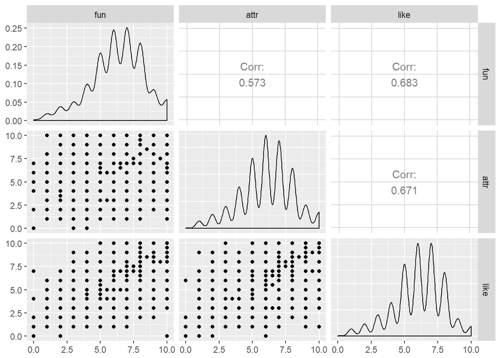

```r
speed_dating_data %>% select(fun, attr, like) %>% ggpairs()
```

```r
# speed_dating_data %>% select(fun, attr, like) %>% corrgram()
```

Podemos perceber que existe uma correlação considerada moderada (Entre 50% e 70%) das variáveis *fun* e *attr* na variável de saída *like*, o que aponta uma forte evidência de que estas influenciem no resultado final de like.  
Se fizermos um modelo de regressão linear para ver a influência das variáveis na variável like, teremos:

## Análise do modelo de regressão linear

```r
mod_fun_attr <- lm(like ~ fun+attr, data = speed_dating_data)
tidy(mod_fun_attr, conf.int = TRUE)
```

```
##          term  estimate  std.error statistic       p.value  conf.low
## 1 (Intercept) 1.0391152 0.06416500  16.19442  1.931667e-57 0.9133217
## 2         fun 0.4153587 0.01073226  38.70190 1.095440e-284 0.3943184
## 3        attr 0.3948057 0.01094067  36.08607 6.266414e-252 0.3733569
##   conf.high
## 1 1.1649087
## 2 0.4363989
## 3 0.4162546
```

Podemos perceber que o modelo estimou para a variável *fun* uma maior influência sobre a variável de saída like, de forma que ela está com um valor muito parecido com o de *attr*.

Acima, podemos retirar informações significantes da tabela, tais quais:  
- *estimate*: significa o coeficiente da variável no modelo, ou seja, o quanto ela influencia na variável de saída.

- *p value*: Medida estatística que indica a significância da influência da variável no variável de saída.
- *conf low e conf high*: Os intervalos de confiança para as coeficientes das variáveis do modelo. Se esses interceptarem o 0, não podemos afirmar que existe significância na influência destes na variável de saída.

Dado que o modelo que estamos analisando se baseia na fórmula `like = (a x fun) + (b x attr)`, onde *a* é o coeficiente estimado no modelo para o quão divertido a pessoa achou o parceiro e *b* o quão bonito a pessoa achou o parceiro, podemos afirmar que:

- O parceiro ser divertido aumenta em, aproximadamente, 0.42 pontos a nota de like.
- O parceiro ser bonito aumenta em, aproximandamente, 0.40 pontos a nota de like.

## Análise dos resíduos do modelo de regressão linear

Vamos analisar os resíduos do nosso modelo para cada variável independente:

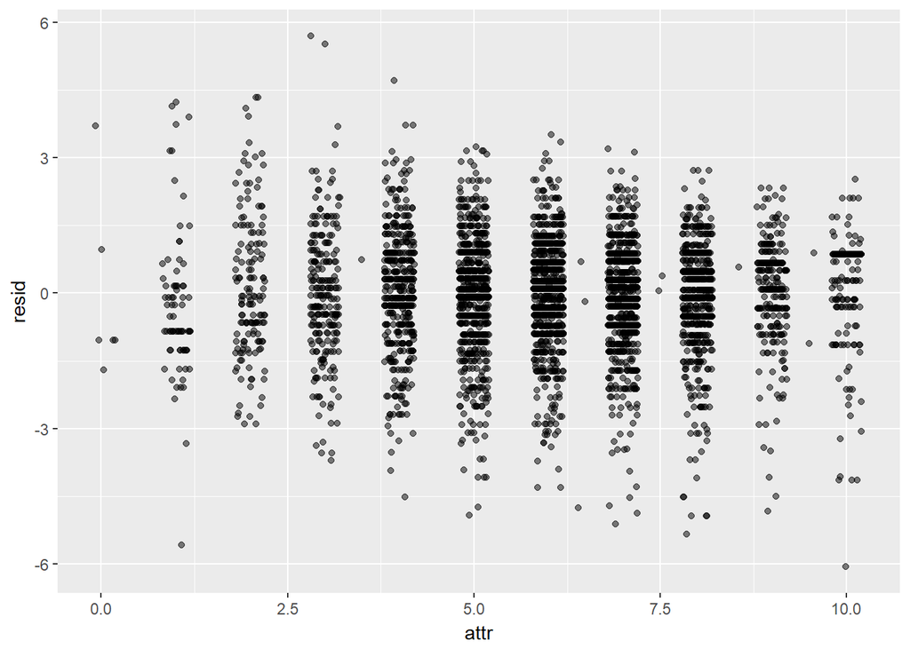

```r
mod_fun_attr_residuos <- speed_dating_data %>%
  add_predictions(mod_fun_attr) %>%
  add_residuals(mod_fun_attr)

mod_fun_attr_residuos %>% ggplot(aes(x=attr)) +geom_jitter(aes(y=resid), alpha=.5)
```

Em geral, os resíduos se concentram entre -3 e 3, o que não é um número muito elevado.

Para a variável fun, temos:

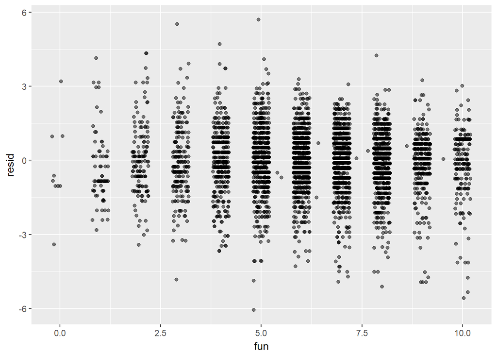

```r
mod_fun_attr_residuos %>% ggplot(aes(x=fun)) +geom_jitter(aes(y=resid), alpha=.5)
```

Para essa variável, aparentemente há um número de resíduos maior, variando entre -3 e 6 pontos em alguns casos. Porém a concentração dos dados se aproxima do resíduo em 0, mostrando que há poucos resíduos.

## Visualização do modelo de regressão linear

Se visualizarmos o modelo graficamente, teremos:

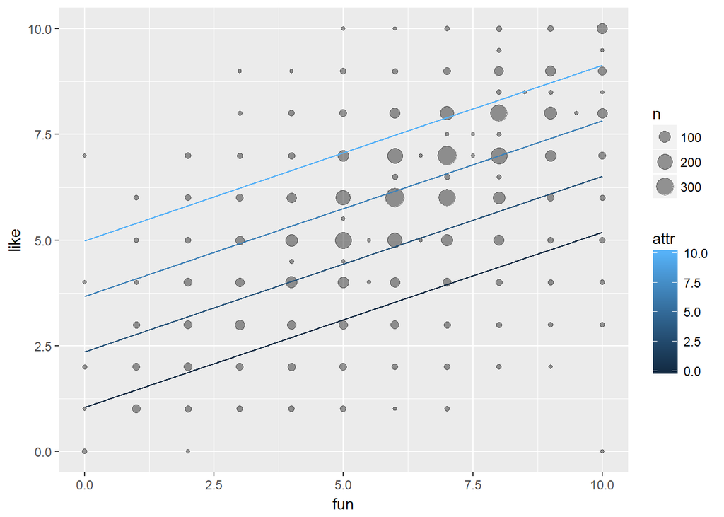

```r
# Esse babado aqui é pra gerar um intervalo de valores que eu quero plotar, só pra orientar
# na leitura do gráfico
p <- speed_dating_data %>%
  data_grid(attr=seq_range(attr, 4), fun=seq_range(fun, 4)) %>%
  add_predictions(model = mod_fun_attr)

speed_dating_data %>%
  ggplot(mapping = aes(x = fun, y = like)) +
  geom_count(alpha = 0.4) +
  geom_line(data= p, aes(y = pred, group=attr, color=attr))  +
  geom_abline(intercept = 69, slope = -.65, color  = "darkblue")
```

O gráfico acima mostra como as duas variáveis se comportam e influenciam like. No eixo x temos o quão divertido a pessoa achou seu parceiro e no eixo y temos a nota de like, a variável de saída. Essas linhas horizontais que interceptam o gráfico são as notas do quão atraente uma pessoa achou seu parceiro. As quatro linhas variam de acordo com a faixa de cores. Na linha mais próxima a zero, a faixa de valores é entre 0 e 2.5, na linha acima varia de 2.5 a 5 e assim sucessivamente.  
A variável like tem sua nota dada pelo cruzamento entre um ponto que intercepta eixo x e a linha horizontal *attr*.  
*n* é o número de votos que foram dados com aquela nota, especificamente.

## Análise do R²

Já mencionamos a significância, relevância e magnitude dos coeficientes acima, além de demonstrar o comportamento do modelo graficamente. Agora vamos entender R², que é o quão bem o meu modelo consegue explicar os dados observados.

```r
glance(mod_fun_attr) %>% select(r.squared, adj.r.squared, sigma, statistic, p.value)
```

```
##   r.squared adj.r.squared    sigma statistic p.value
## 1 0.5826971     0.5825195 1.190388  3281.401       0
```

De acordo com o cálculo acima, usando a biblioteca *broom*, temos que o nosso modelo consegue explicar 58% da variação observada para a variável like.

# Segunda pergunta: Em geral, qual gênero é mais confiante com relação a um segundo encontro?

Podemos reformular essa pergunta para que ela seja respondida corretamente usando os conceitos de estatística e análise dos dados que dispomos. Desse modo, ela fica assim: “A probabilidade que a pessoa acha que o parceiro tem que de querer se encontrar com ela novamente é influenciada pelo gênero (da pessoa) e pelo quão bonito a pessoa achou o parceiro?”. Confuso, certo? Mas imagine o seguinte: Existem mitos sobre a autoconfiança nos gêneros. Existem pessoas que dizem que os homens são mais autoconfiantes e outras que dizem que mulheres são mais autoconfiantes. A variável *prob* nos diz a probabilidade que p1 acha que p2 tem de querer se encontrar novamente com ele, certo? Então, teoricamente, quanto maior a nota, mais autoconfiança uma pessoa tem sobre o quão bem foi o seu encontro. Agora vamos verificar a variação disso em função do gênero e do quão bonito p1 achou p2. Quanto mais bonito, será que essa probabilidade diminui? Ou seja, a autoconfiança é influenciada pela beleza do parceiro?

Vamos ver!

## Análise do modelo de regressão linear

```r
mod_confianca <- lm(prob ~ gender+attr, data = speed_dating_data)
tidy(mod_confianca, conf.int = TRUE)
```

```
##          term   estimate  std.error statistic       p.value   conf.low
## 1 (Intercept)  3.2712595 0.10056278  32.52952 9.794125e-210  3.0741098
## 2     gender1 -0.1169365 0.06119577  -1.91086  5.608273e-02 -0.2369086
## 3        attr  0.2971861 0.01572188  18.90272  6.772767e-77  0.2663640
##     conf.high
## 1 3.468409169
## 2 0.003035537
## 3 0.328008309
```

De acordo com o modelo acima, os homens (gênero 1) são menos confiantes do que as mulheres nos encontros. Porém, ao analisarmos a significância percebemos que não podemos afirmar relevância significativa para as diferenças de gênero na confiança com relação a um segundo encontro. Isso, entretanto, se prende aos termos técnicos e gerais da estatística, pois ele fica na limiar entre haver diferença e não haver diferença. É algo a ser discutido e pesquisado com mais afinco.

Ao analisarmos a nossa segunda variável, a beleza do parceiro, vemos que há uma influência positiva desta na variável *prob*. Ou seja, quanto mais p1 acha p2 bonito, maior a probabilidade que p1 acha que p2 quer se encontrar com ele novamente.

## Análise dos resíduos do modelo de regressão linear

Analisando a variável de beleza, temos:

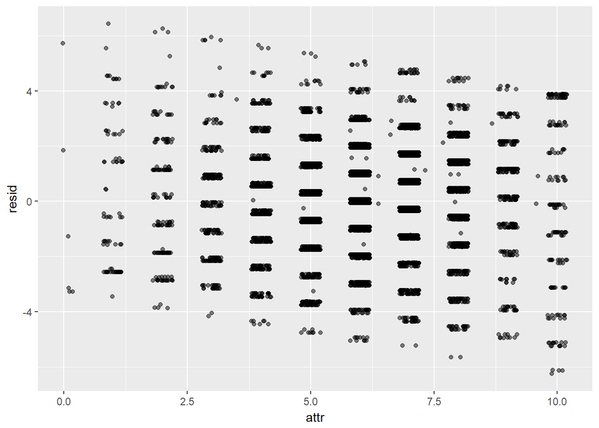

```r
mod_conf_residuos <- speed_dating_data %>%
  add_predictions(mod_confianca) %>%
  add_residuals(mod_confianca)

mod_conf_residuos %>% ggplot(aes(x=attr)) +geom_jitter(aes(y=resid), alpha=.5)
```

Os resíduos variam entre 4 e -4, o que parece ser não tão alto. Os resíduos aparecem com frequência próximos ao 0.

Se analisarmos o gênero, temos:

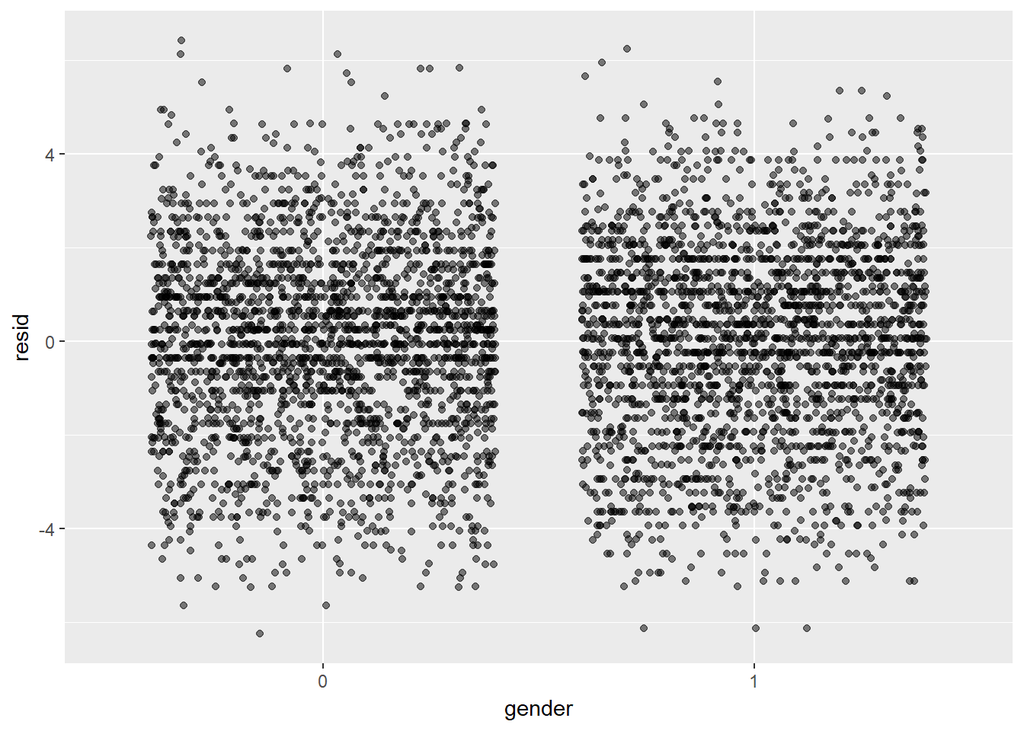

```r
mod_conf_residuos %>% ggplot(aes(x=gender)) +geom_jitter(aes(y=resid), alpha=.5)
```

Basicamente aparece a mesma faixa de valores, e há uma maior frequência dos resíduos próximos ao 0.

## Análise do R²

Vamos analisar o nosso R² e ver o quão bem esse modelo explica a nossa variável de saída.

```r
glance(mod_confianca) %>% select(r.squared, adj.r.squared, sigma, statistic, p.value)
```

```
##    r.squared adj.r.squared    sigma statistic      p.value
## 1 0.07007195    0.06968032 2.088659  178.9233 1.210543e-75
```

Confesso que estou bem triste, esperava um R² maior com relação à essa análise… Mas é isso! Podemos concluir que essas variáveis, gênero e beleza, não explicam muito bem a questão da autoconfiança e a probabilidade que p1 acha que p2 tem de querer se encontrar com ele novamente.

Essa foi a análise dessa semana, espero que tenham curtido! Até a próxima.